# Differential analysis with DESeq2 with no ampicillin treatment

Authors: Huijing Wang and Christian Ray

- In this analysis, /*all gene statistics*/ are saved to .csv files for facilitating further analysis.
- The normalized counts were also saved.
- The adjusted p value (FDR) threshold is set to 0.05 for identifying significant.
- Removing all the ampicillin-treated replicates for this analysis.

# Load package

```r
library("DESeq2")
library("EnhancedVolcano")
```

# Load data

```r
control_gene_index = as.integer(scan("./non_regulated_gene_index_for_R.txt", what = "integer", sep = ","))

control_gene_index[1:10]
```

Sample names refer to condition: T0 is without ampicillin treatment T1 is after ampicillin treatment OD is from a pilot RNA-seq run, not ampicillin treatment L01: 0.1 mg/ml lactose in Davis minimal medium L25: 2.5 mg/ml lactose in Davis minimal medium L50: 50 mg/ml lactose in Davis minimal medium

```r
# load the data
# round to integer values
countfile = './counts_no_amp.csv'
countsdata = read.csv(countfile, sep=",", header=TRUE,row.names=1 )
countsdata = round(countsdata, digits = 0)
head(countsdata,4)
```

# Remove OD.L50.01

```r
# remove the outlier samples
countsdata$OD.L50.01 = NULL
countsdata$T0.L25.10 = NULL
```

```r
dim(countsdata)[1] -2
```

```r
dim(countsdata)
```

```r
countsdata[1,]
```

```r
# The last two genes in the countsdata object are not part of the transcriptome fastq.
for (i in range(dim(countsdata)[1] - 2)){
  if (sum(countsdata[i,]>=1)==0){print(countsdata[i,])}
}
```

# Function: Systematically rename all the columns

There were repeated names after changing the “OD” prefix to “T0”. This is not desirable. I need to change the column names that there are not repetitive. I am not sure if I am going to meet similar problems. But if I do, I supposed I have some certain *pattern*, and then find this *pattern* in all my column names, and then change the column names system matically.

```r
sys_naming = function(dataset, condition) {

  # This function takes in a dataset, which should be an R dataframe, where each row is a variable, and each column is a sample name. The function will take in both the data frame and the condition names, as an indicator to return a systematically renamed dataframe.
  # input:
  # dataset - the count dataframe
  # condition - a named vector for conditions, where the vector are the new patterns, and the name of the vector are the patterns that occurred in the column names
  # output:
  # new_dataset - dataframe with systematically re-named columns

  name_vector = colnames(dataset)    # obtain the column names

  new_name = substr(name_vector,1,6)    # for loop for replacing all the condition names
  for ( i in 1:length(condition)) {
    new_name = gsub(names(condition[i]), condition[[i]], new_name)
  }

  num_string = gsub(" ", "0", format(1:length(name_vector), trim = FALSE))    # column numbering
  new_name_vector = paste(new_name, num_string, sep = "")    # the new column names

  names(name_vector) = new_name_vector    # named vector that index the new name will trace back to its old names
  #print(name_vector)

  return(name_vector)
}
```

```r
# use the function sys_naming to change the dataframe column names.
conditions = c("pre_lac01_", "pre_lac25_", "pre_lac50_", "pst_lac01_", "pst_lac50_", "pre_lac01_", "pre_lac25_", "pre_lac50_")
names(conditions) = c("T0.L01", "T0.L25", "T0.L50", "T1.L01", "T1.L50", "OD.L01", "OD.L25", "OD.L50")
new_con_names = sys_naming(countsdata, conditions)

counts_data_qc = countsdata
colnames(counts_data_qc) = names(new_con_names)    # change dataframe column names
colnames(counts_data_qc)
```

# Create handle dataframe

```r
sample = colnames(counts_data_qc)
handle = data.frame(row.names = sample)

handle$condition_all = substr(sample, 1,9)
handle$lactose = substr(handle$condition_all,5,9)

#handle$lactose = gsub("lac01", "0.1 mg/ml - low",handle$lactose)
#handle$lactose = gsub("lac25", "2.5 mg/ml - mid",handle$lactose)
#handle$lactose = gsub("lac50", "50 mg/ml - high",handle$lactose)

handle$ampicillin = substr(handle$condition_all,1,3)

View(handle)
all(rownames(handle)==colnames(countsdata))
```

```r
dim(countsdata)
```

# Differential gene expression analysis

Then let us define the differential analysis object. Note the design formula, a GLM for addition of all conditions. Other designs could be considered.

Perform the differential analysis

```r
reflist = c("pre_lac01","pre_lac25", "pre_lac50")
```

### Function: volcanoplot

```r
# volcano plot
# desfolder - folder for containing the files

myvolcano = function(result_matrix, result_condition, desfolder, refhere, p_bar = 0.05){

  # reorder the results according to the p value
  resOrdered <- result_matrix[order(result_matrix$pvalue),]

  # create a subpath for reference condition in the desfolder
  subdir = paste(desfolder,"/",refhere, sep = "")
  if (dir.exists(subdir) == FALSE) {dir.create(subdir)}

  # define pdf path
  plotname = paste(subdir, "/", substr(result_condition,15,36),".pdf", sep = "")
  pdf(plotname, width=5.5, height=6)
  # select significant DE data
  result_sig <- subset(resOrdered, padj < p_bar)
  volcano = EnhancedVolcano(
    result_sig,
    lab = rownames(result_sig),
    #selectLab = result_sig@rownames[1:30],
    selectLab = c(),
    pCutoff = p_bar,
    FCcutoff = 2,
    title = substr(result_condition,15,30),
    x = "log2FoldChange", y = "pvalue",
    xlab = bquote(~Log[2]~ "fold change"), ylab = bquote(~-Log[10]~italic(FDR))
    )
  print(volcano)
  dev.off()
}
```

```r
# print and save summary log
summarylog = function(result_matrix, result_condition, desfolder, refhere, p_bar = 0.05, getall=0){

  summary(result_matrix, alpha = p_bar)

  # create a subpath for reference condition in the desfolder
  subdir = paste(desfolder,"/",refhere, sep = "")
  if (dir.exists(subdir) == FALSE) {dir.create(subdir)}

  # export summary to a txt file
  result_summary <- capture.output(summary(result_matrix, alpha = p_bar))
  cat(
    result_summary,
    file=paste(subdir, "/", substr(result_condition,15,36), "_summary", ".txt", sep = ""),
    sep="\n", append=FALSE)
}

# export results as .csv file
resultcsv = function(result_matrix, result_condition, desfolder, refhere, p_bar = 0.05, getall=0){

  # If getall = 0, then the .csv records only significant genes
  # If getall = 1, then the .csv records the entire gene record

  # We can order our results table by the smallest p value
  resOrdered <- result_matrix[order(result_matrix$pvalue),]

  # export data
  if (getall==1){result_sig <- subset(resOrdered)}
  else {result_sig <- subset(resOrdered, padj < p_bar)}
  # create a subpath for reference condition in the desfolder
  subdir = paste(desfolder,"/",refhere, sep = "")
  if (dir.exists(subdir) == FALSE) {dir.create(subdir)}

  # define pdf path
  csvname = paste(subdir, "/", substr(result_condition,15,36), ".csv", sep = "")
  print(csvname)
  write.csv(as.data.frame(result_sig), file=csvname)
}
```

```r
deseqloop = function(dataobject, reflist, volcanodir, csvdir){
  dds_de_list = list()
  for (i in c(1:length(reflist))) {
    # factor function is available for targeted comparisions
    print(reflist[i])
    dataobject$condition_all <- relevel(dataobject$condition_all, ref = reflist[i])

    # DE analysis
    #dds_de = DESeq(dataobject, test = "Wald")
    dds_de <- estimateSizeFactors(dataobject, controlGenes = control_gene_index)
    #dds_de <- estimateSizeFactors(dataobject)
    dds_de <- estimateDispersions(dds_de)
    dds_de <- nbinomWaldTest(dds_de)

    dds_de_list[i]=dds_de

    # print results names
    renames = resultsNames(dds_de)

    # print size factor
    size_factor = dds_de@colData@listData$sizeFactor    # the size factor for each replica
    print(size_factor)
    DESeq2_norm = counts(dds_de, normalized=TRUE)    # obtain the normalized counts for each replica
    normfile = paste(csvdir, "/", "norm_count.csv", sep='')
    write.csv(as.data.frame(DESeq2_norm), file=normfile)


    for (j in c(2:length(renames))){
      res = lfcShrink(dds_de, coef=j, type="apeglm")
      # create volcano plot
      myvolcano(res, renames[j], volcanodir, reflist[i], p_bar = 0.05)
      # create csv files
      resultcsv(res, renames[j], csvdir, reflist[i], p_bar = 0.05 , getall=1)
      summarylog(res, renames[j], csvdir, reflist[i], p_bar = 0.05 , getall=1)
    }
  }
  names(dds_de_list) = reflist
  return(dds_de_list)
}
```

```r
vofolder = "./DE-Volcano"

if (!file.exists(vofolder)) {
 dir.create(file.path(vofolder))
}

csvfolder = "./DE-CSVs"
if (!file.exists(csvfolder)) {
 dir.create(file.path(csvfolder))
}

ddsObj <- DESeqDataSetFromMatrix(countData = counts_data_qc,
                              colData = handle,
                              design = ~ condition_all)
```

```
Warning: some variables in design formula are characters, converting to factors
```

```r
de_object = deseqloop(ddsObj, reflist, vofolder, csvfolder)
```

```
[1] "pre_lac01"
```

```
Warning: implicit list embedding of S4 objects is deprecated
```

```
pre_lac25_01 pre_lac01_02 pre_lac25_03 pre_lac01_04 pre_lac01_05 pre_lac25_06 pre_lac25_07 pre_lac25_08
   2.0063860    0.6439513    1.5741777    0.6430215    0.2355806    1.4402238    1.3132107    1.5650256
pre_lac50_09 pre_lac50_10 pre_lac50_11 pre_lac50_12 pre_lac50_13 pre_lac50_14 pre_lac50_15 pre_lac50_16
   1.5569641    1.3829635    1.2914327    0.8370405    0.9244118    1.3184434    1.2249185    1.2708795
pre_lac01_17 pre_lac25_18 pre_lac25_19 pre_lac01_20 pre_lac01_21 pre_lac01_22 pre_lac25_23
   0.1918216    1.5677568    1.2054784    1.1077157    0.3749831    0.8859241    1.2152850
```

```
using 'apeglm' for LFC shrinkage. If used in published research, please cite:
    Zhu, A., Ibrahim, J.G., Love, M.I. (2018) Heavy-tailed prior distributions for
    sequence count data: removing the noise and preserving large differences.
    Bioinformatics. https://doi.org/10.1093/bioinformatics/bty895
Warning: Ignoring unknown parameters: xlim, ylim
```

```
[1] "./DE-CSVs/pre_lac01/pre_lac25_vs_pre_lac01.csv"

out of 4489 with nonzero total read count
adjusted p-value < 0.05
LFC > 0 (up)       : 1615, 36%
LFC < 0 (down)     : 1527, 34%
outliers [1]       : 2, 0.045%
low counts [2]     : 0, 0%
(mean count < 0)
[1] see 'cooksCutoff' argument of ?results
[2] see 'independentFiltering' argument of ?results

[1] "./DE-CSVs/pre_lac01/pre_lac50_vs_pre_lac01.csv"

out of 4489 with nonzero total read count
adjusted p-value < 0.05
LFC > 0 (up)       : 1475, 33%
LFC < 0 (down)     : 716, 16%
outliers [1]       : 2, 0.045%
low counts [2]     : 0, 0%
(mean count < 0)
[1] see 'cooksCutoff' argument of ?results
[2] see 'independentFiltering' argument of ?results

[1] "pre_lac25"
pre_lac25_01 pre_lac01_02 pre_lac25_03 pre_lac01_04 pre_lac01_05 pre_lac25_06 pre_lac25_07 pre_lac25_08
   2.0063860    0.6439513    1.5741777    0.6430215    0.2355806    1.4402238    1.3132107    1.5650256
pre_lac50_09 pre_lac50_10 pre_lac50_11 pre_lac50_12 pre_lac50_13 pre_lac50_14 pre_lac50_15 pre_lac50_16
   1.5569641    1.3829635    1.2914327    0.8370405    0.9244118    1.3184434    1.2249185    1.2708795
pre_lac01_17 pre_lac25_18 pre_lac25_19 pre_lac01_20 pre_lac01_21 pre_lac01_22 pre_lac25_23
   0.1918216    1.5677568    1.2054784    1.1077157    0.3749831    0.8859241    1.2152850
[1] "./DE-CSVs/pre_lac25/pre_lac01_vs_pre_lac25.csv"

out of 4489 with nonzero total read count
adjusted p-value < 0.05
LFC > 0 (up)       : 1527, 34%
LFC < 0 (down)     : 1615, 36%
outliers [1]       : 2, 0.045%
low counts [2]     : 0, 0%
(mean count < 0)
```

[output cut: 30 more lines]

```
(mean count < 0)
[1] see 'cooksCutoff' argument of ?results
[2] see 'independentFiltering' argument of ?results

[1] "./DE-CSVs/pre_lac50/pre_lac01_vs_pre_lac50.csv"

out of 4489 with nonzero total read count
adjusted p-value < 0.05
LFC > 0 (up)       : 716, 16%
LFC < 0 (down)     : 1475, 33%
outliers [1]       : 2, 0.045%
low counts [2]     : 0, 0%
(mean count < 0)
[1] see 'cooksCutoff' argument of ?results
[2] see 'independentFiltering' argument of ?results
```

```r
de_object
```

```
$pre_lac01
class: DESeqDataSet
dim: 4490 23
metadata(1): version
assays(4): counts mu H cooks
rownames(4490): ECB_RS00005 ECB_RS00010 ... pGFP MicL-S
rowData names(26): baseMean baseVar ... deviance maxCooks
colnames(23): pre_lac25_01 pre_lac01_02 ... pre_lac01_22 pre_lac25_23
colData names(4): condition_all lactose ampicillin sizeFactor

$pre_lac25
class: DESeqDataSet
dim: 4490 23
metadata(1): version
assays(4): counts mu H cooks
rownames(4490): ECB_RS00005 ECB_RS00010 ... pGFP MicL-S
rowData names(26): baseMean baseVar ... deviance maxCooks
colnames(23): pre_lac25_01 pre_lac01_02 ... pre_lac01_22 pre_lac25_23
colData names(4): condition_all lactose ampicillin sizeFactor

$pre_lac50
class: DESeqDataSet
dim: 4490 23
metadata(1): version
assays(4): counts mu H cooks
rownames(4490): ECB_RS00005 ECB_RS00010 ... pGFP MicL-S
rowData names(26): baseMean baseVar ... deviance maxCooks
colnames(23): pre_lac25_01 pre_lac01_02 ... pre_lac01_22 pre_lac25_23
colData names(4): condition_all lactose ampicillin sizeFactor
```

```
using 'apeglm' for LFC shrinkage. If used in published research, please cite:
    Zhu, A., Ibrahim, J.G., Love, M.I. (2018) Heavy-tailed prior distributions for
    sequence count data: removing the noise and preserving large differences.
    Bioinformatics. https://doi.org/10.1093/bioinformatics/bty895
```

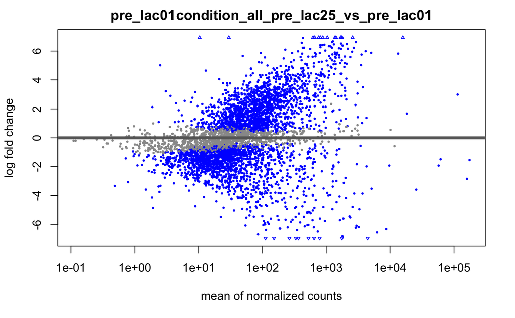

```
using 'apeglm' for LFC shrinkage. If used in published research, please cite:
    Zhu, A., Ibrahim, J.G., Love, M.I. (2018) Heavy-tailed prior distributions for
    sequence count data: removing the noise and preserving large differences.
    Bioinformatics. https://doi.org/10.1093/bioinformatics/bty895
```

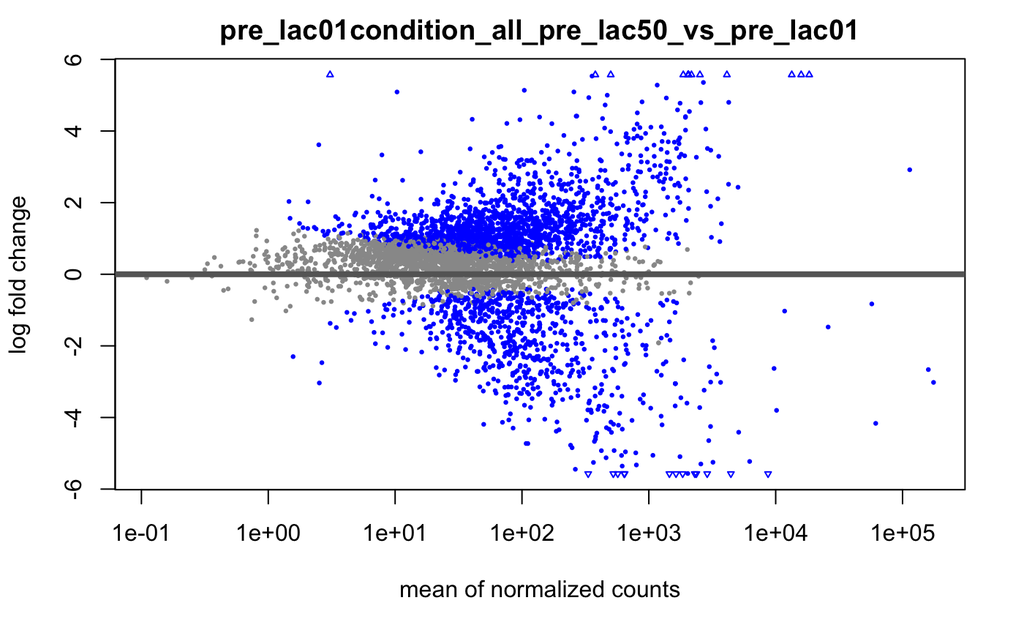

```
using 'apeglm' for LFC shrinkage. If used in published research, please cite:
    Zhu, A., Ibrahim, J.G., Love, M.I. (2018) Heavy-tailed prior distributions for
    sequence count data: removing the noise and preserving large differences.
    Bioinformatics. https://doi.org/10.1093/bioinformatics/bty895
```

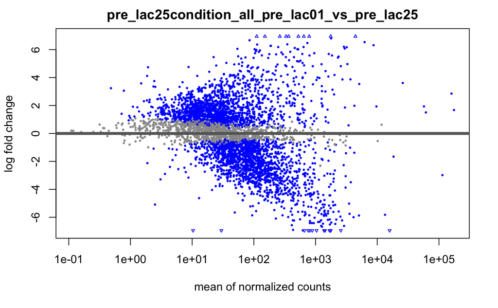

```
using 'apeglm' for LFC shrinkage. If used in published research, please cite:
    Zhu, A., Ibrahim, J.G., Love, M.I. (2018) Heavy-tailed prior distributions for
    sequence count data: removing the noise and preserving large differences.
    Bioinformatics. https://doi.org/10.1093/bioinformatics/bty895
```

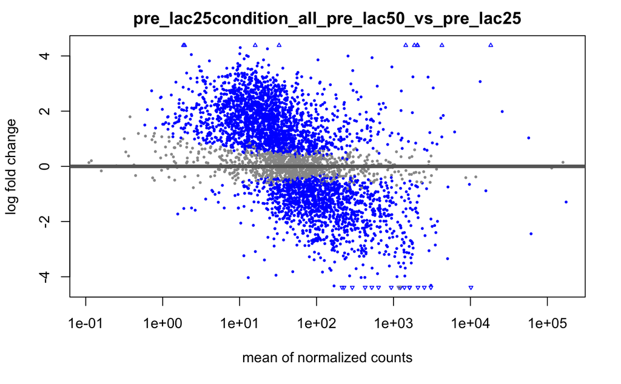

```
using 'apeglm' for LFC shrinkage. If used in published research, please cite:
    Zhu, A., Ibrahim, J.G., Love, M.I. (2018) Heavy-tailed prior distributions for
    sequence count data: removing the noise and preserving large differences.
    Bioinformatics. https://doi.org/10.1093/bioinformatics/bty895
```

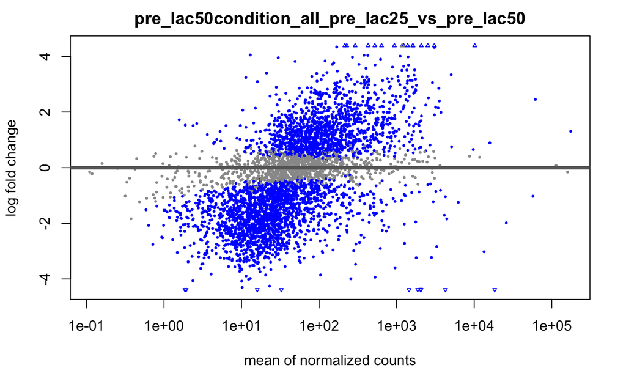

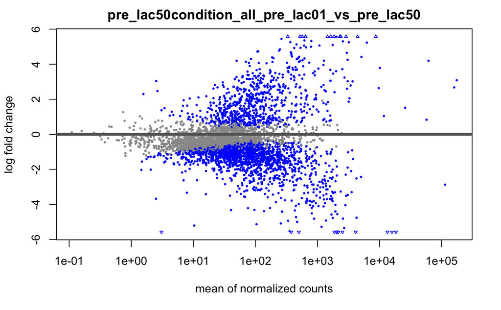

```r
i = 1
while (i<=length(de_object)) {

  j = 2
  while(j<=length(resultsNames(de_object[[i]]))){
    resLFC <- lfcShrink(de_object[[i]], coef=j, type="apeglm")
    plotMA(resLFC, alpha = 0.1, main = paste(reflist[i], resultsNames(de_object[[i]])[[j]], sep = "" ))
    j = j+1
  }

  i = i+1
}
```

```r
resLFC <- lfcShrink(de_object[[1]], coef=2, type="apeglm")
```

```
using 'apeglm' for LFC shrinkage. If used in published research, please cite:
    Zhu, A., Ibrahim, J.G., Love, M.I. (2018) Heavy-tailed prior distributions for
    sequence count data: removing the noise and preserving large differences.
    Bioinformatics. https://doi.org/10.1093/bioinformatics/bty895
```

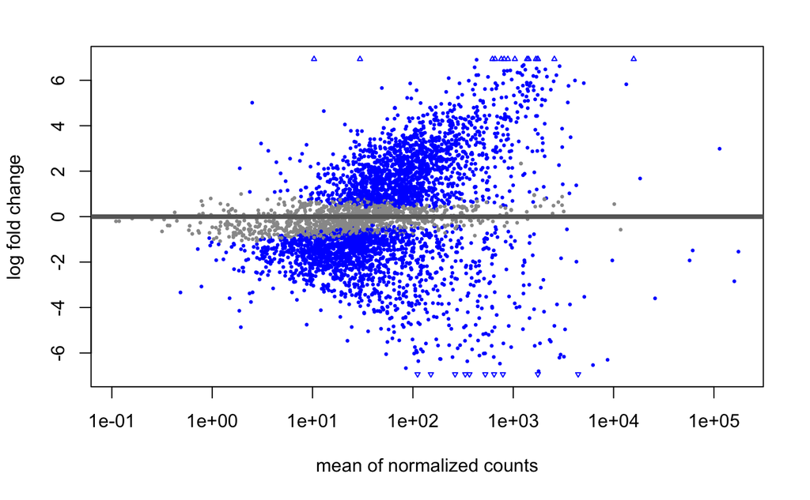

```r
plotMA(resLFC)
```